# Stats Lecture 2023-11-22

Adam Tallman

2023-11-22

## P-values review

install the follwing packages

```r
library(nhstplot)
library(rlist)
```

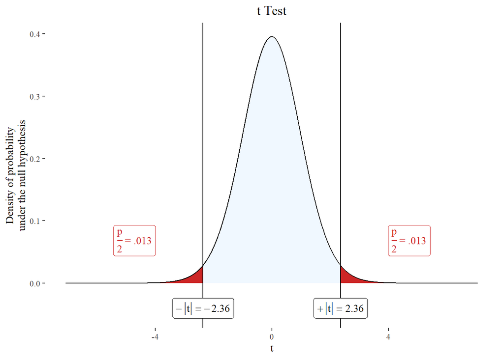

```r
set.seed(1234)
n <- 30
vowel.durations <- rnorm(n, mean = 80, sd=10)
h1 <- c("strong","weak")
h1 <- sample(h1, n, replace=TRUE, prob=c(0.5, 0.5))
h2 <- c("strong","weak")
h2 <- sample(h2, n, replace=TRUE, prob=c(0.5, 0.5))
h3 <- c("strong","weak")
h3 <- sample(h3, n, replace=TRUE, prob=c(0.5, 0.5))
h4 <- c("strong","weak")
h4 <- sample(h4, n, replace=TRUE, prob=c(0.5, 0.5))
h5 <- c("strong","weak")
h5 <- sample(h5, n, replace=TRUE, prob=c(0.5, 0.5))
h6 <- c("strong","weak")
h6 <- sample(h6, n, replace=TRUE, prob=c(0.5, 0.5))
df <- data.frame(vowel.durations, h1,h2,h3,h4,h5,h6)
plotttest(t.test(vowel.durations~h4, data=df))
```

```r
set.seed(123)
n <- 5
strong.vowels <- rnorm(n, mean = 85, sd = 10)
weak.vowels <- rnorm(n, mean = 80, sd = 10)
strong <- rep("yes", times =n, length.out=n)
weak <- rep("no", times =n, length.out=n)
vowel.durations <- list.append(strong.vowels, weak.vowels)
prominence <- list.append(strong, weak)
t <- (mean(strong.vowels) - mean(weak.vowels)) / (sqrt((var(strong.vowels)/n) + (var(weak.vowels)/n)))
t
```

```
## [1] 1.163376
```

We can see that the p-val is higher than 0.05

[figure not shown]

```r
plotttest(t.test(vowel.durations~prominence), tails = "one")
```

Let’s look at a simple linear model

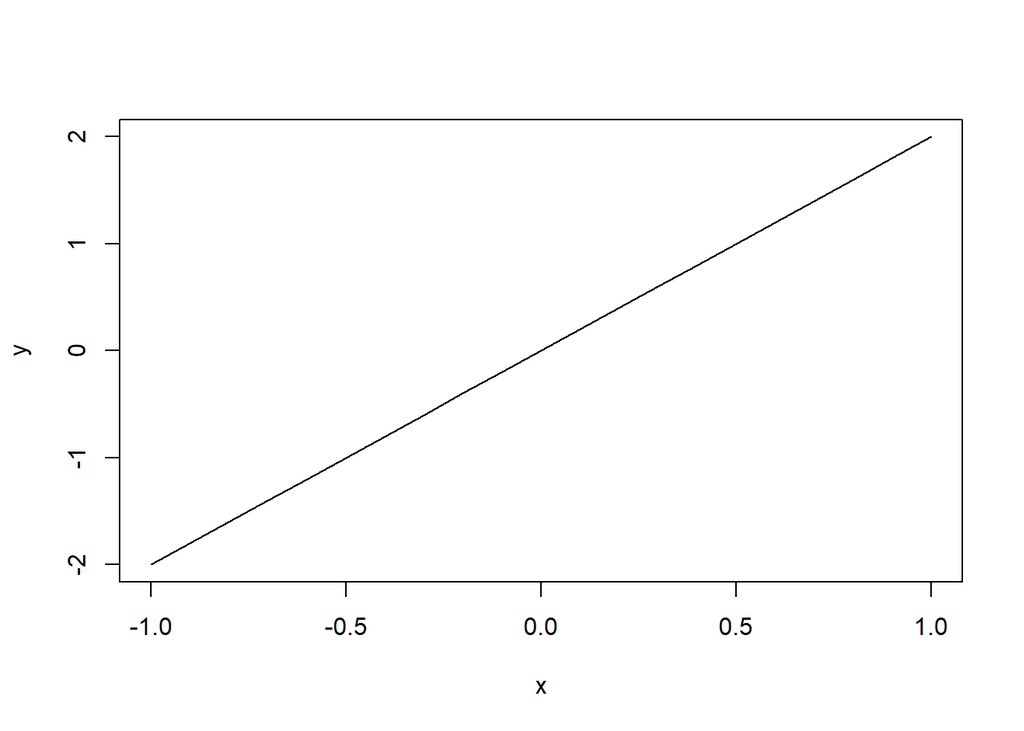

```r
#x <- rnorm(20, 10, 4)
x <- seq(from = -1, to =1, by =0.1)
a <- 0
b <- 2
y <- a + b*x

plot(x, y, type = "l", lty = 1)
```

You can also plot each of the data points which fall on the line as well

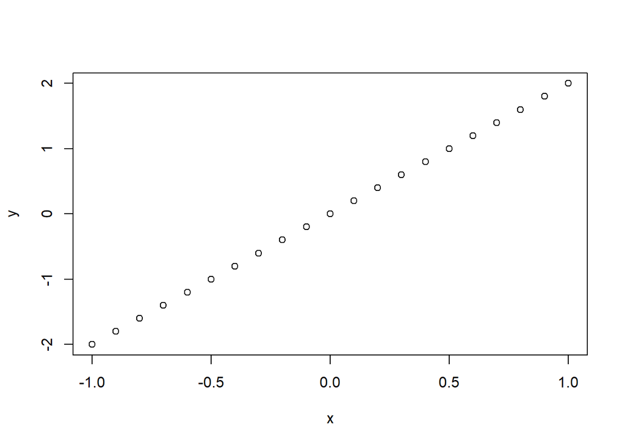

```r
plot(y~x)
```

What happens if you change the formula.

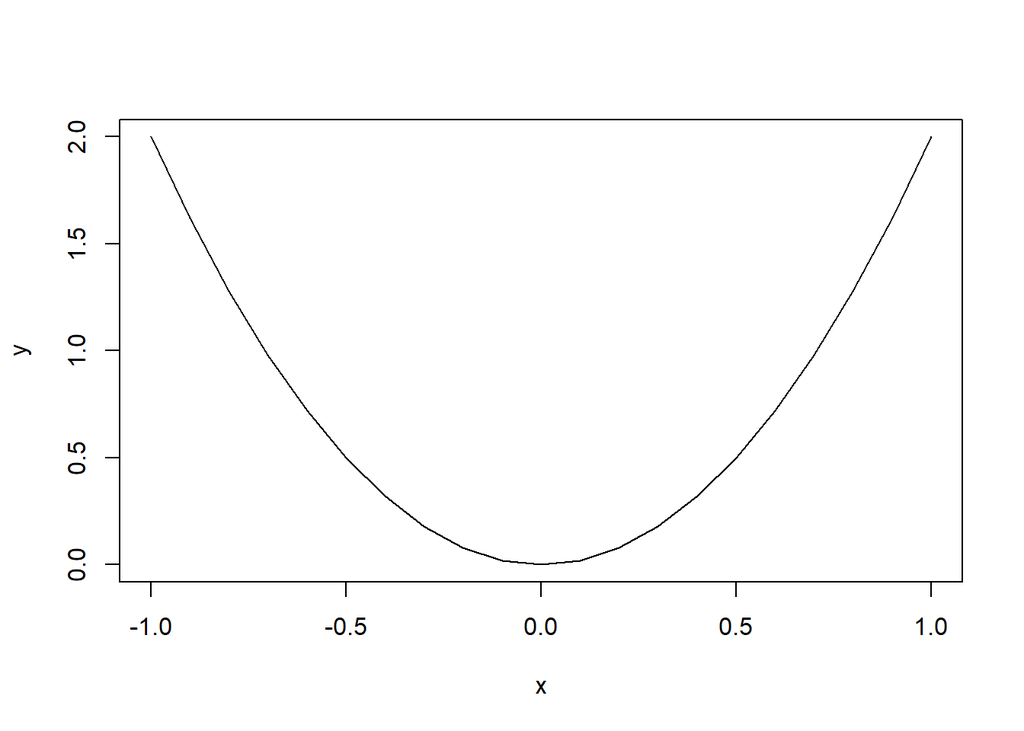

```r
x <- seq(from = -1, to =1, by =0.1)
a <- 0
b <- 2
y <- a + b*x^2
plot(x, y, type = "l", lty = 1)
```

To produce what I have in the slides you just set the xlim differently.

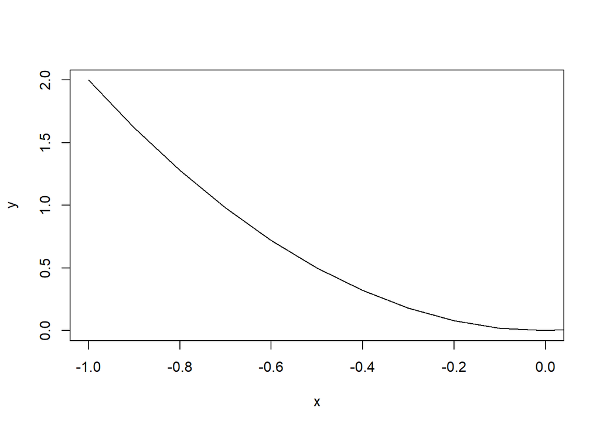

```r
plot(x, y, type = "l", lty = 1, xlim = c(-1, 0))
```

Here’s how I got the ldt file (but use your own path of course)

```r
install.packages("/Users/Adan Tallman/Desktop/Rling_1.0.tar.gz", repos = NULL, type = "source")
library(Rling)
data(ldt)
write.csv(ldt, file="/Users/Adan Tallman/Desktop/ldt.csv")
```

Let’s look at the data

```r
library(tidyverse)
glimpse(ldt)
```

```
## Rows: 100
## Columns: 3
## $ Length  <int> 8, 10, 7, 6, 12, 12, 3, 11, 11, 5, 6, 6, 11, 4, 11, 8, 10, 10,…
## $ Freq    <int> 131, 82, 0, 592, 2, 9, 14013, 15, 48, 290, 3264, 3523, 46, 173…
## $ Mean_RT <dbl> 819.19, 977.63, 908.22, 766.30, 1125.42, 948.33, 641.67, 816.9…
```

```r
summary(ldt)
```

```
##      Length           Freq            Mean_RT
##  Min.   : 3.00   Min.   :    0.0   Min.   : 564.2
##  1st Qu.: 6.00   1st Qu.:   53.5   1st Qu.: 713.1
##  Median : 8.00   Median :  310.5   Median : 784.9
##  Mean   : 8.23   Mean   : 3350.3   Mean   : 808.3
##  3rd Qu.:10.00   3rd Qu.: 2103.2   3rd Qu.: 905.2
##  Max.   :15.00   Max.   :75075.0   Max.   :1458.8
```

```r
head(ldt)
```

```
##              Length Freq Mean_RT
## marveled          8  131  819.19
## persuaders       10   82  977.63
## midmost           7    0  908.22
## crutch            6  592  766.30
## resuspension     12    2 1125.42
## efflorescent     12    9  948.33
```

Let’s plot the mn reaction time by the length of the word

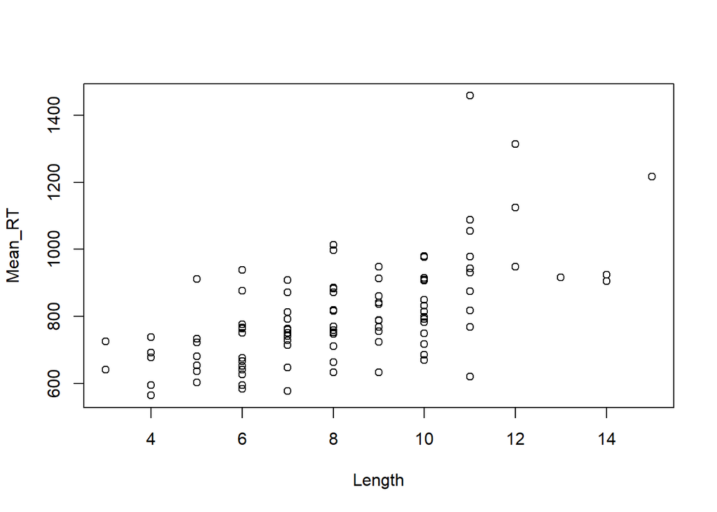

```r
attach(ldt)
plot(Mean_RT~Length)
```

Take a guess at where you think the line should be and what its coefficient should be.

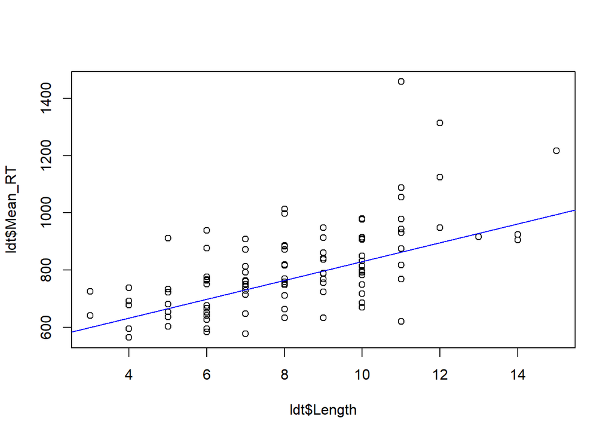

```
## integer(0)
```

```r
plot(ldt$Length, ldt$Mean_RT)+ abline(a=500, b=33, col="blue")
```

You can get the best fit relationship by using lm()

```r
lm(Mean_RT~Length, data=ldt)
```

```
##
## Call:
## lm(formula = Mean_RT ~ Length, data = ldt)
##
## Coefficients:
## (Intercept)       Length
##      498.44        37.64
```

You can graph it in ggplot with the following code

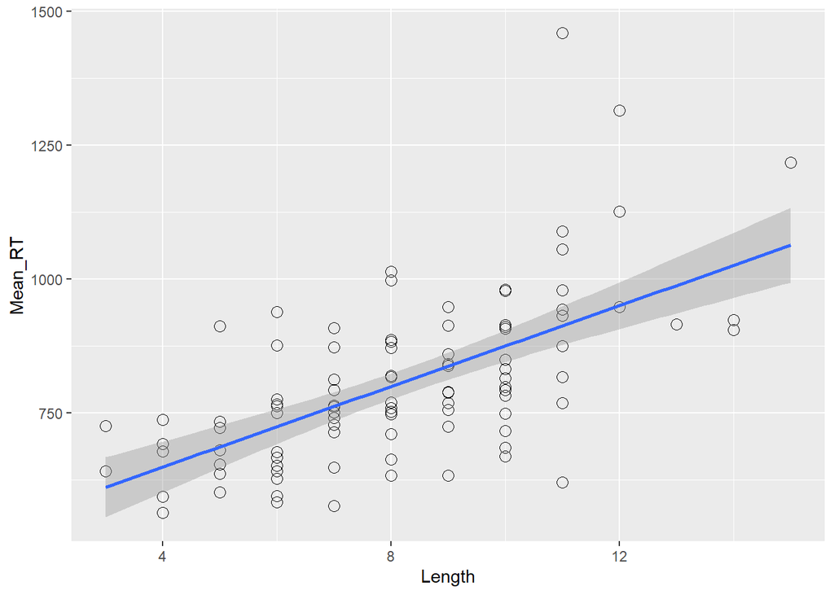

```r
ggplot(ldt, aes(x=Length, y = Mean_RT))+
geom_point(shape=1, size=3)+stat_smooth(method=lm)
```

But how do you get the best fit? Go back to slides for discussion.

```r
library(truncnorm)

set.seed(1)
school <- sample(c("good", "bad"), size=30, replace=30)
school.binary <- ifelse(school == "good", 1, 0)
class.grade <- as.integer(rtruncnorm(a=0, b=100, m = 40, sd=15, n =30))
intercept <- 0
b1 <- 15
b2 <- 1
error <- rnorm(m=0, sd=10, n=30)
test.score <- intercept +  b1*school.binary +b2*class.grade + error
test.score <- ifelse(test.score < 0, 0, test.score)
test.score <- ifelse(test.score> 100, 100, test.score)
test.score <- as.integer(test.score)
data <- data.frame(test.score, school, class.grade)
```

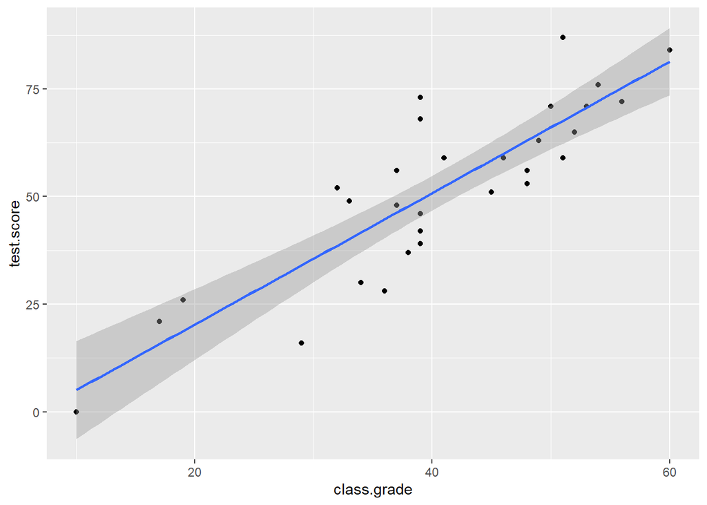

```r
ggplot(data,aes(class.grade, test.score)) +
  geom_point()+
  geom_smooth(method='lm')
```

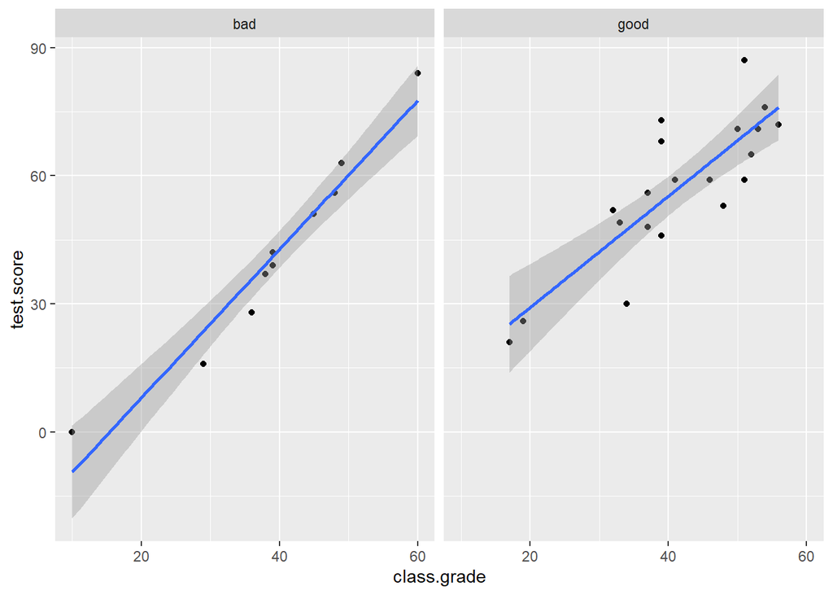

```r
ggplot(data,aes(class.grade, test.score)) +
  geom_point()+
  geom_smooth(method='lm')+
  facet_wrap(~school)
```

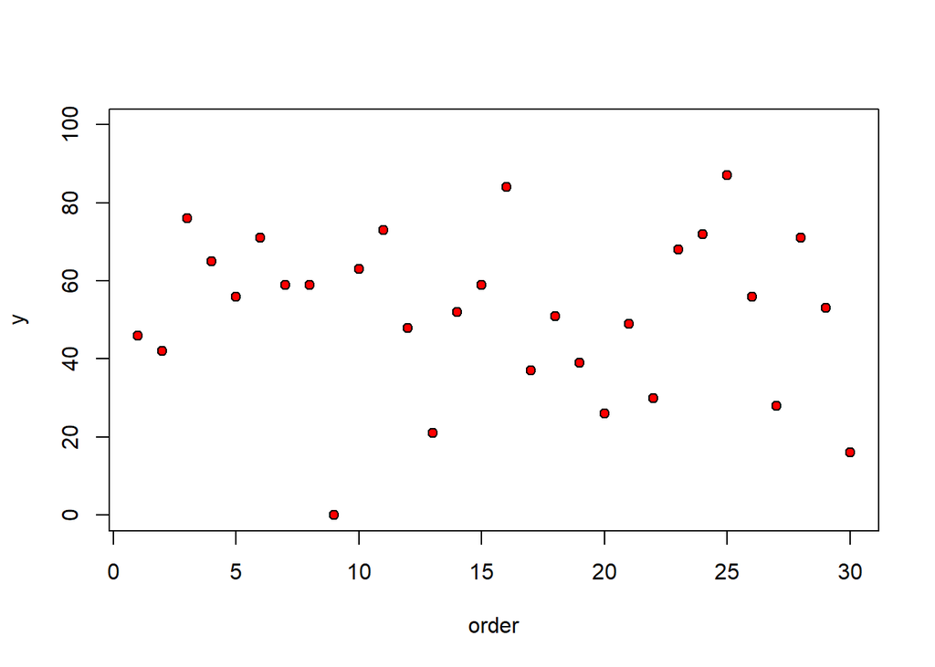

```r
plot(1:30,test.score,ylim=c(0,100),ylab="y",xlab="order",pch=21,bg="red")
```

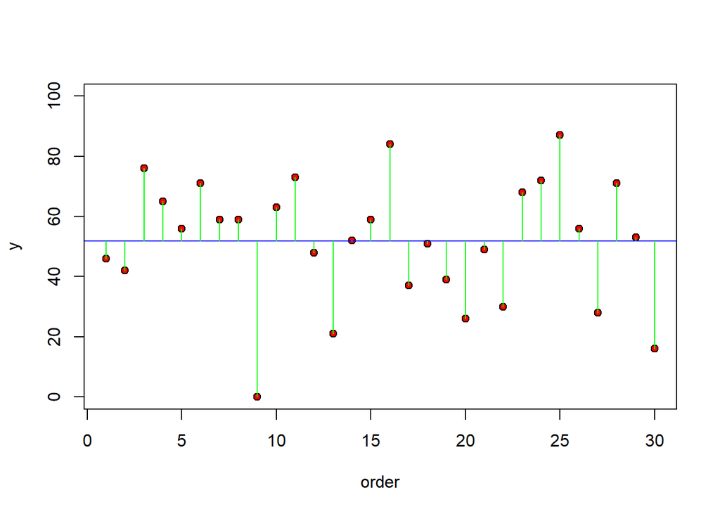

```r
plot(1:30,test.score,ylim=c(0,100),ylab="y",xlab="order",pch=21,bg="red")
abline(h=mean(test.score),col="blue")
for(i in 1:100) lines(c(i,i),c(mean(test.score),test.score[i]),col="green")
```

```r
SSY <- sum(test.score - mean(test.score))
```

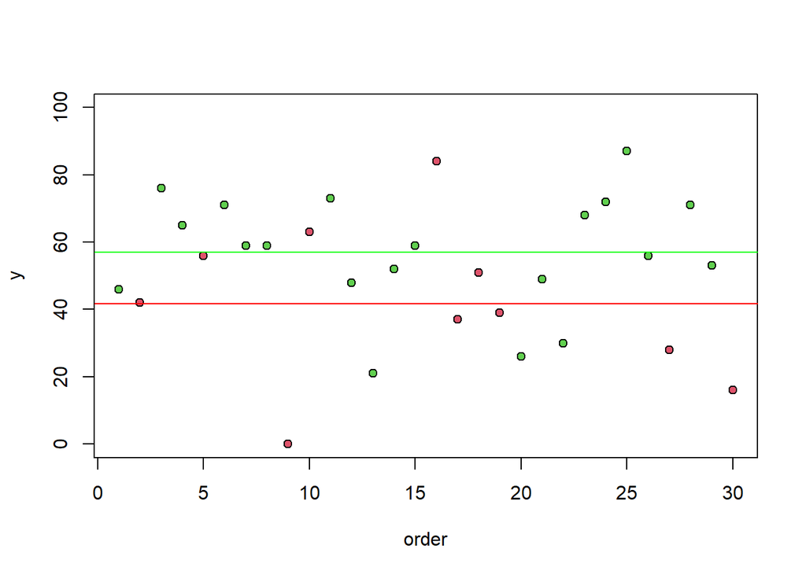

```r
plot(1:30,test.score,ylim=c(0,100),ylab="y",xlab="order", pch=21,bg= as.numeric(as.factor(school))+1 )
abline(h=mean(test.score[school=="good"]),col="green")
abline(h=mean(test.score[school=="bad"]), col="red")
```

```r
SSEgood <- sum((test.score[school=="good"]-mean(test.score[school=="good"]))^2)
SSEbad <- sum((test.score[school=="bad"]-mean(test.score[school=="bad"]))^2)
SSE = SSEgood + SSEbad
```

```r
SSG = SSY - SSE
SSG
```

```
## [1] -10775.35
```